# Risk Factor Analysis

## Outcome Variable

**Outcome Variable:** wasted

## Predictor Variables

**Intervention Variable:** hhwealth_quart

**Adjustment Set:**

unadjusted

## Stratifying Variables

The analysis was stratified on these variable(s):

- agecat
- studyid
- country

## Data Summary

| agecat | studyid | country | hhwealth_quart | wasted | n_cell | n |
| --- | --- | --- | --- | --- | --- | --- |
| Birth | CMC-V-BCS-2002 | INDIA | Wealth Q4 | 0 | 26 | 86 |
| Birth | CMC-V-BCS-2002 | INDIA | Wealth Q4 | 1 | 6 | 86 |
| Birth | CMC-V-BCS-2002 | INDIA | Wealth Q1 | 0 | 12 | 86 |
| Birth | CMC-V-BCS-2002 | INDIA | Wealth Q1 | 1 | 1 | 86 |
| Birth | CMC-V-BCS-2002 | INDIA | Wealth Q2 | 0 | 16 | 86 |
| Birth | CMC-V-BCS-2002 | INDIA | Wealth Q2 | 1 | 3 | 86 |
| Birth | CMC-V-BCS-2002 | INDIA | Wealth Q3 | 0 | 21 | 86 |
| Birth | CMC-V-BCS-2002 | INDIA | Wealth Q3 | 1 | 1 | 86 |
| Birth | COHORTS | GUATEMALA | Wealth Q4 | 0 | 190 | 729 |
| Birth | COHORTS | GUATEMALA | Wealth Q4 | 1 | 68 | 729 |
| Birth | COHORTS | GUATEMALA | Wealth Q1 | 0 | 98 | 729 |
| Birth | COHORTS | GUATEMALA | Wealth Q1 | 1 | 46 | 729 |
| Birth | COHORTS | GUATEMALA | Wealth Q2 | 0 | 108 | 729 |
| Birth | COHORTS | GUATEMALA | Wealth Q2 | 1 | 33 | 729 |
| Birth | COHORTS | GUATEMALA | Wealth Q3 | 0 | 148 | 729 |
| Birth | COHORTS | GUATEMALA | Wealth Q3 | 1 | 38 | 729 |
| Birth | COHORTS | PHILIPPINES | Wealth Q4 | 0 | 671 | 2898 |
| Birth | COHORTS | PHILIPPINES | Wealth Q4 | 1 | 144 | 2898 |
| Birth | COHORTS | PHILIPPINES | Wealth Q1 | 0 | 533 | 2898 |
| Birth | COHORTS | PHILIPPINES | Wealth Q1 | 1 | 114 | 2898 |
| Birth | COHORTS | PHILIPPINES | Wealth Q2 | 0 | 442 | 2898 |
| Birth | COHORTS | PHILIPPINES | Wealth Q2 | 1 | 64 | 2898 |
| Birth | COHORTS | PHILIPPINES | Wealth Q3 | 0 | 801 | 2898 |
| Birth | COHORTS | PHILIPPINES | Wealth Q3 | 1 | 129 | 2898 |
| Birth | CONTENT | PERU | Wealth Q4 | 0 | 0 | 2 |
| Birth | CONTENT | PERU | Wealth Q4 | 1 | 0 | 2 |
| Birth | CONTENT | PERU | Wealth Q1 | 0 | 0 | 2 |
| Birth | CONTENT | PERU | Wealth Q1 | 1 | 0 | 2 |
| Birth | CONTENT | PERU | Wealth Q2 | 0 | 1 | 2 |
| Birth | CONTENT | PERU | Wealth Q2 | 1 | 0 | 2 |

[output cut: 386 more lines]

The following strata were considered:

- agecat: 24 months, studyid: CMC-V-BCS-2002, country: INDIA
- agecat: 24 months, studyid: COHORTS, country: GUATEMALA
- agecat: 24 months, studyid: COHORTS, country: PHILIPPINES
- agecat: 24 months, studyid: CONTENT, country: PERU
- agecat: 24 months, studyid: GMS-Nepal, country: NEPAL
- agecat: 24 months, studyid: IRC, country: INDIA
- agecat: 24 months, studyid: JiVitA-3, country: BANGLADESH
- agecat: 24 months, studyid: JiVitA-4, country: BANGLADESH
- agecat: 24 months, studyid: LCNI-5, country: MALAWI
- agecat: 24 months, studyid: MAL-ED, country: BANGLADESH
- agecat: 24 months, studyid: MAL-ED, country: BRAZIL
- agecat: 24 months, studyid: MAL-ED, country: INDIA
- agecat: 24 months, studyid: MAL-ED, country: NEPAL
- agecat: 24 months, studyid: MAL-ED, country: PERU
- agecat: 24 months, studyid: MAL-ED, country: SOUTH AFRICA
- agecat: 24 months, studyid: MAL-ED, country: TANZANIA, UNITED REPUBLIC OF
- agecat: 24 months, studyid: PROVIDE, country: BANGLADESH
- agecat: 24 months, studyid: TanzaniaChild2, country: TANZANIA, UNITED REPUBLIC OF
- agecat: 6 months, studyid: CMC-V-BCS-2002, country: INDIA
- agecat: 6 months, studyid: COHORTS, country: GUATEMALA
- agecat: 6 months, studyid: COHORTS, country: PHILIPPINES
- agecat: 6 months, studyid: CONTENT, country: PERU
- agecat: 6 months, studyid: GMS-Nepal, country: NEPAL
- agecat: 6 months, studyid: IRC, country: INDIA
- agecat: 6 months, studyid: JiVitA-3, country: BANGLADESH
- agecat: 6 months, studyid: JiVitA-4, country: BANGLADESH
- agecat: 6 months, studyid: LCNI-5, country: MALAWI
- agecat: 6 months, studyid: MAL-ED, country: BANGLADESH
- agecat: 6 months, studyid: MAL-ED, country: BRAZIL
- agecat: 6 months, studyid: MAL-ED, country: INDIA
- agecat: 6 months, studyid: MAL-ED, country: NEPAL
- agecat: 6 months, studyid: MAL-ED, country: PERU
- agecat: 6 months, studyid: MAL-ED, country: SOUTH AFRICA
- agecat: 6 months, studyid: MAL-ED, country: TANZANIA, UNITED REPUBLIC OF
- agecat: 6 months, studyid: PROVIDE, country: BANGLADESH
- agecat: 6 months, studyid: TanzaniaChild2, country: TANZANIA, UNITED REPUBLIC OF
- agecat: Birth, studyid: CMC-V-BCS-2002, country: INDIA
- agecat: Birth, studyid: COHORTS, country: GUATEMALA
- agecat: Birth, studyid: COHORTS, country: PHILIPPINES
- agecat: Birth, studyid: CONTENT, country: PERU
- agecat: Birth, studyid: GMS-Nepal, country: NEPAL
- agecat: Birth, studyid: IRC, country: INDIA
- agecat: Birth, studyid: JiVitA-3, country: BANGLADESH
- agecat: Birth, studyid: JiVitA-4, country: BANGLADESH
- agecat: Birth, studyid: MAL-ED, country: BANGLADESH
- agecat: Birth, studyid: MAL-ED, country: BRAZIL
- agecat: Birth, studyid: MAL-ED, country: INDIA
- agecat: Birth, studyid: MAL-ED, country: NEPAL
- agecat: Birth, studyid: MAL-ED, country: PERU
- agecat: Birth, studyid: MAL-ED, country: SOUTH AFRICA
- agecat: Birth, studyid: MAL-ED, country: TANZANIA, UNITED REPUBLIC OF
- agecat: Birth, studyid: PROVIDE, country: BANGLADESH

### Dropped Strata

Some strata were dropped due to rare outcomes:

- agecat: Birth, studyid: CMC-V-BCS-2002, country: INDIA
- agecat: Birth, studyid: CONTENT, country: PERU
- agecat: Birth, studyid: MAL-ED, country: BRAZIL
- agecat: Birth, studyid: MAL-ED, country: INDIA
- agecat: Birth, studyid: MAL-ED, country: NEPAL
- agecat: Birth, studyid: MAL-ED, country: PERU
- agecat: Birth, studyid: MAL-ED, country: SOUTH AFRICA
- agecat: Birth, studyid: MAL-ED, country: TANZANIA, UNITED REPUBLIC OF
- agecat: 6 months, studyid: CONTENT, country: PERU
- agecat: 6 months, studyid: LCNI-5, country: MALAWI
- agecat: 6 months, studyid: MAL-ED, country: BANGLADESH
- agecat: 6 months, studyid: MAL-ED, country: BRAZIL
- agecat: 6 months, studyid: MAL-ED, country: INDIA
- agecat: 6 months, studyid: MAL-ED, country: NEPAL
- agecat: 6 months, studyid: MAL-ED, country: PERU
- agecat: 6 months, studyid: MAL-ED, country: SOUTH AFRICA
- agecat: 6 months, studyid: MAL-ED, country: TANZANIA, UNITED REPUBLIC OF
- agecat: 24 months, studyid: CMC-V-BCS-2002, country: INDIA
- agecat: 24 months, studyid: CONTENT, country: PERU
- agecat: 24 months, studyid: LCNI-5, country: MALAWI
- agecat: 24 months, studyid: MAL-ED, country: BANGLADESH
- agecat: 24 months, studyid: MAL-ED, country: BRAZIL
- agecat: 24 months, studyid: MAL-ED, country: NEPAL
- agecat: 24 months, studyid: MAL-ED, country: PERU
- agecat: 24 months, studyid: MAL-ED, country: SOUTH AFRICA
- agecat: 24 months, studyid: MAL-ED, country: TANZANIA, UNITED REPUBLIC OF
- agecat: 24 months, studyid: TanzaniaChild2, country: TANZANIA, UNITED REPUBLIC OF

## Methods Detail

We’re interested in the causal parameters $E[Y_a]$ for all values of $a \in \mathcal{A}$. These parameters represent the mean outcome if, possibly contrary to fact, we intervened to set all units to have $A=a$. Under the randomization and positivity assumptions, these are identified by the statistical parameters $\psi_a=E_W[E_{Y|A,W}(Y|A=a,W)]$. In addition, we’re interested in the mean of $Y$, $E[Y]$ under no intervention (the observed mean). We will estimate these parameters by using SuperLearner to fit the relevant likelihood factors – $E_{Y|A,W}(Y|A=a,W)$ and $p(A=a|W)$, and then updating our likelihood fit using a joint TMLE.

For unadjusted analyses ($W=\{\}$), initial likelihoods were estimated using Lrnr_glm to estimate the simple $E(Y|A)$ and Lrnr_mean to estimate $p(A)$. For adjusted analyses, a small library containing Lrnr_glmnet, Lrnr_xgboost, and Lrnr_mean was used.

Having estimated these parameters, we will then use the delta method to estimate relative risks and attributable risks relative to a prespecified baseline level of $A$.

# Results Detail

## Results Plots

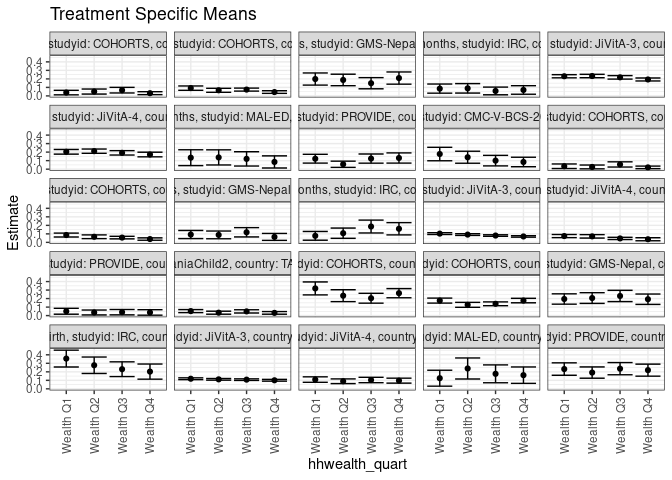

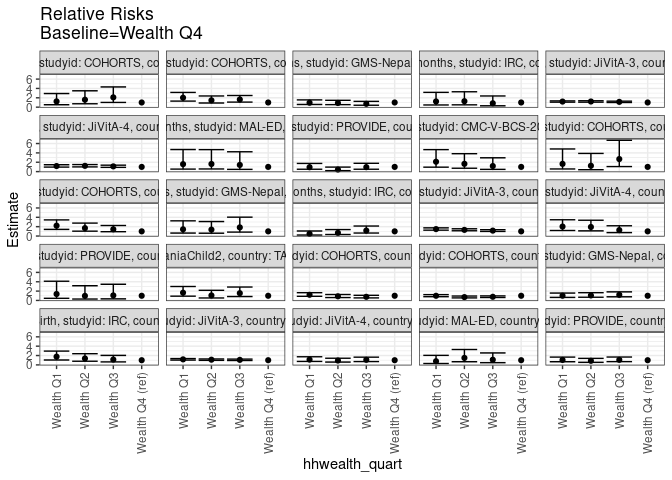

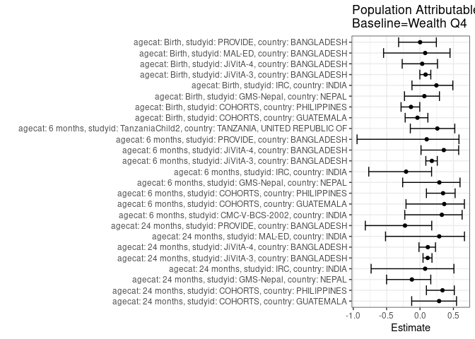

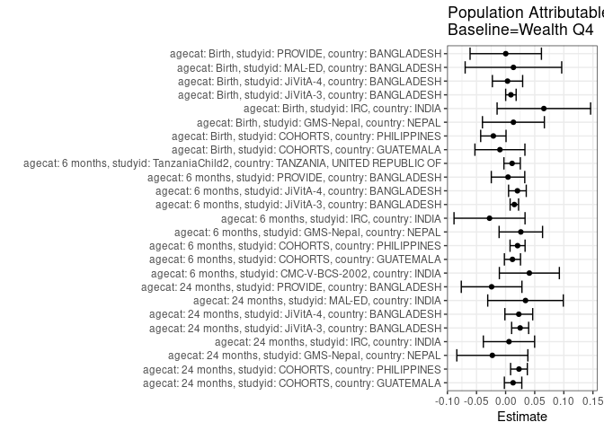

## Results Table

### Parameter: TSM

| agecat | studyid | country | intervention_level | baseline_level | estimate | ci_lower | ci_upper |
| --- | --- | --- | --- | --- | --- | --- | --- |
| Birth | COHORTS | GUATEMALA | Wealth Q4 | NA | 0.2635659 | 0.2097702 | 0.3173616 |
| Birth | COHORTS | GUATEMALA | Wealth Q1 | NA | 0.3194444 | 0.2432375 | 0.3956514 |
| Birth | COHORTS | GUATEMALA | Wealth Q2 | NA | 0.2340426 | 0.1641089 | 0.3039762 |
| Birth | COHORTS | GUATEMALA | Wealth Q3 | NA | 0.2043011 | 0.1463182 | 0.2622839 |
| Birth | COHORTS | PHILIPPINES | Wealth Q4 | NA | 0.1766871 | 0.1504975 | 0.2028767 |
| Birth | COHORTS | PHILIPPINES | Wealth Q1 | NA | 0.1761978 | 0.1468360 | 0.2055596 |
| Birth | COHORTS | PHILIPPINES | Wealth Q2 | NA | 0.1264822 | 0.0975156 | 0.1554489 |
| Birth | COHORTS | PHILIPPINES | Wealth Q3 | NA | 0.1387097 | 0.1164914 | 0.1609279 |
| Birth | GMS-Nepal | NEPAL | Wealth Q4 | NA | 0.1925466 | 0.1315928 | 0.2535004 |
| Birth | GMS-Nepal | NEPAL | Wealth Q1 | NA | 0.1951220 | 0.1344227 | 0.2558212 |
| Birth | GMS-Nepal | NEPAL | Wealth Q2 | NA | 0.2062500 | 0.1435069 | 0.2689931 |
| Birth | GMS-Nepal | NEPAL | Wealth Q3 | NA | 0.2307692 | 0.1646021 | 0.2969363 |
| Birth | IRC | INDIA | Wealth Q4 | NA | 0.2025316 | 0.1137810 | 0.2912823 |
| Birth | IRC | INDIA | Wealth Q1 | NA | 0.3555556 | 0.2565163 | 0.4545948 |
| Birth | IRC | INDIA | Wealth Q2 | NA | 0.2771084 | 0.1806801 | 0.3735367 |
| Birth | IRC | INDIA | Wealth Q3 | NA | 0.2307692 | 0.1440773 | 0.3174612 |
| Birth | JiVitA-3 | BANGLADESH | Wealth Q4 | NA | 0.1005549 | 0.0903049 | 0.1108050 |
| Birth | JiVitA-3 | BANGLADESH | Wealth Q1 | NA | 0.1186020 | 0.1079661 | 0.1292380 |
| Birth | JiVitA-3 | BANGLADESH | Wealth Q2 | NA | 0.1114835 | 0.1019743 | 0.1209926 |
| Birth | JiVitA-3 | BANGLADESH | Wealth Q3 | NA | 0.1081258 | 0.0987368 | 0.1175149 |
| Birth | JiVitA-4 | BANGLADESH | Wealth Q4 | NA | 0.0961538 | 0.0670216 | 0.1252861 |
| Birth | JiVitA-4 | BANGLADESH | Wealth Q1 | NA | 0.1089286 | 0.0766397 | 0.1412174 |
| Birth | JiVitA-4 | BANGLADESH | Wealth Q2 | NA | 0.0891410 | 0.0616835 | 0.1165985 |
| Birth | JiVitA-4 | BANGLADESH | Wealth Q3 | NA | 0.1038760 | 0.0723944 | 0.1353575 |
| Birth | MAL-ED | BANGLADESH | Wealth Q4 | NA | 0.1607143 | 0.0642827 | 0.2571459 |
| Birth | MAL-ED | BANGLADESH | Wealth Q1 | NA | 0.1250000 | 0.0312072 | 0.2187928 |
| Birth | MAL-ED | BANGLADESH | Wealth Q2 | NA | 0.2391304 | 0.1155571 | 0.3627038 |
| Birth | MAL-ED | BANGLADESH | Wealth Q3 | NA | 0.1764706 | 0.0715836 | 0.2813576 |
| Birth | PROVIDE | BANGLADESH | Wealth Q4 | NA | 0.2196970 | 0.1489980 | 0.2903960 |
| Birth | PROVIDE | BANGLADESH | Wealth Q1 | NA | 0.2325581 | 0.1595871 | 0.3055291 |

[output cut: 70 more lines]

### Parameter: E(Y)

| agecat | studyid | country | intervention_level | baseline_level | estimate | ci_lower | ci_upper |
| --- | --- | --- | --- | --- | --- | --- | --- |
| Birth | COHORTS | GUATEMALA | NA | NA | 0.2537723 | 0.2221611 | 0.2853834 |
| Birth | COHORTS | PHILIPPINES | NA | NA | 0.1556246 | 0.1424244 | 0.1688248 |
| Birth | GMS-Nepal | NEPAL | NA | NA | 0.2059282 | 0.1745993 | 0.2372572 |
| Birth | IRC | INDIA | NA | NA | 0.2682216 | 0.2212677 | 0.3151755 |
| Birth | JiVitA-3 | BANGLADESH | NA | NA | 0.1096477 | 0.1045230 | 0.1147723 |
| Birth | JiVitA-4 | BANGLADESH | NA | NA | 0.0994152 | 0.0840401 | 0.1147903 |
| Birth | MAL-ED | BANGLADESH | NA | NA | 0.1741294 | 0.1215730 | 0.2266857 |
| Birth | PROVIDE | BANGLADESH | NA | NA | 0.2199248 | 0.1846953 | 0.2551543 |
| 6 months | CMC-V-BCS-2002 | INDIA | NA | NA | 0.1250000 | 0.0911644 | 0.1588356 |
| 6 months | COHORTS | GUATEMALA | NA | NA | 0.0323974 | 0.0209875 | 0.0438073 |
| 6 months | COHORTS | PHILIPPINES | NA | NA | 0.0594974 | 0.0505830 | 0.0684118 |
| 6 months | GMS-Nepal | NEPAL | NA | NA | 0.0904255 | 0.0667359 | 0.1141152 |
| 6 months | IRC | INDIA | NA | NA | 0.1323529 | 0.0994307 | 0.1652752 |
| 6 months | JiVitA-3 | BANGLADESH | NA | NA | 0.0845851 | 0.0797798 | 0.0893904 |
| 6 months | JiVitA-4 | BANGLADESH | NA | NA | 0.0569712 | 0.0481278 | 0.0658146 |
| 6 months | PROVIDE | BANGLADESH | NA | NA | 0.0414594 | 0.0255348 | 0.0573839 |
| 6 months | TanzaniaChild2 | TANZANIA, UNITED REPUBLIC OF | NA | NA | 0.0430906 | 0.0342310 | 0.0519502 |
| 24 months | COHORTS | GUATEMALA | NA | NA | 0.0449331 | 0.0323731 | 0.0574931 |
| 24 months | COHORTS | PHILIPPINES | NA | NA | 0.0681911 | 0.0582056 | 0.0781766 |
| 24 months | GMS-Nepal | NEPAL | NA | NA | 0.1868583 | 0.1522030 | 0.2215136 |
| 24 months | IRC | INDIA | NA | NA | 0.0757946 | 0.0501131 | 0.1014762 |
| 24 months | JiVitA-3 | BANGLADESH | NA | NA | 0.2180591 | 0.2081778 | 0.2279404 |
| 24 months | JiVitA-4 | BANGLADESH | NA | NA | 0.1945032 | 0.1812962 | 0.2077102 |
| 24 months | MAL-ED | INDIA | NA | NA | 0.1189427 | 0.0767376 | 0.1611478 |
| 24 months | PROVIDE | BANGLADESH | NA | NA | 0.1070812 | 0.0818727 | 0.1322897 |

### Parameter: RR

| agecat | studyid | country | intervention_level | baseline_level | estimate | ci_lower | ci_upper |
| --- | --- | --- | --- | --- | --- | --- | --- |
| Birth | COHORTS | GUATEMALA | Wealth Q4 | Wealth Q4 | 1.0000000 | 1.0000000 | 1.0000000 |
| Birth | COHORTS | GUATEMALA | Wealth Q1 | Wealth Q4 | 1.2120098 | 0.8854314 | 1.6590419 |
| Birth | COHORTS | GUATEMALA | Wealth Q2 | Wealth Q4 | 0.8879850 | 0.6183722 | 1.2751500 |
| Birth | COHORTS | GUATEMALA | Wealth Q3 | Wealth Q4 | 0.7751423 | 0.5464613 | 1.0995208 |
| Birth | COHORTS | PHILIPPINES | Wealth Q4 | Wealth Q4 | 1.0000000 | 1.0000000 | 1.0000000 |
| Birth | COHORTS | PHILIPPINES | Wealth Q1 | Wealth Q4 | 0.9972308 | 0.7978792 | 1.2463908 |
| Birth | COHORTS | PHILIPPINES | Wealth Q2 | Wealth Q4 | 0.7158542 | 0.5449403 | 0.9403732 |
| Birth | COHORTS | PHILIPPINES | Wealth Q3 | Wealth Q4 | 0.7850582 | 0.6311349 | 0.9765209 |
| Birth | GMS-Nepal | NEPAL | Wealth Q4 | Wealth Q4 | 1.0000000 | 1.0000000 | 1.0000000 |
| Birth | GMS-Nepal | NEPAL | Wealth Q1 | Wealth Q4 | 1.0133753 | 0.6501540 | 1.5795173 |
| Birth | GMS-Nepal | NEPAL | Wealth Q2 | Wealth Q4 | 1.0711694 | 0.6905336 | 1.6616190 |
| Birth | GMS-Nepal | NEPAL | Wealth Q3 | Wealth Q4 | 1.1985112 | 0.7818969 | 1.8371080 |
| Birth | IRC | INDIA | Wealth Q4 | Wealth Q4 | 1.0000000 | 1.0000000 | 1.0000000 |
| Birth | IRC | INDIA | Wealth Q1 | Wealth Q4 | 1.7555556 | 1.0445037 | 2.9506601 |
| Birth | IRC | INDIA | Wealth Q2 | Wealth Q4 | 1.3682229 | 0.7818797 | 2.3942734 |
| Birth | IRC | INDIA | Wealth Q3 | Wealth Q4 | 1.1394231 | 0.6397558 | 2.0293445 |
| Birth | JiVitA-3 | BANGLADESH | Wealth Q4 | Wealth Q4 | 1.0000000 | 1.0000000 | 1.0000000 |
| Birth | JiVitA-3 | BANGLADESH | Wealth Q1 | Wealth Q4 | 1.1794749 | 1.0274562 | 1.3539857 |
| Birth | JiVitA-3 | BANGLADESH | Wealth Q2 | Wealth Q4 | 1.1086822 | 0.9728176 | 1.2635217 |
| Birth | JiVitA-3 | BANGLADESH | Wealth Q3 | Wealth Q4 | 1.0752910 | 0.9383492 | 1.2322179 |
| Birth | JiVitA-4 | BANGLADESH | Wealth Q4 | Wealth Q4 | 1.0000000 | 1.0000000 | 1.0000000 |
| Birth | JiVitA-4 | BANGLADESH | Wealth Q1 | Wealth Q4 | 1.1328571 | 0.7394251 | 1.7356257 |
| Birth | JiVitA-4 | BANGLADESH | Wealth Q2 | Wealth Q4 | 0.9270665 | 0.6024351 | 1.4266304 |
| Birth | JiVitA-4 | BANGLADESH | Wealth Q3 | Wealth Q4 | 1.0803101 | 0.7059639 | 1.6531579 |
| Birth | MAL-ED | BANGLADESH | Wealth Q4 | Wealth Q4 | 1.0000000 | 1.0000000 | 1.0000000 |
| Birth | MAL-ED | BANGLADESH | Wealth Q1 | Wealth Q4 | 0.7777778 | 0.2975830 | 2.0328390 |
| Birth | MAL-ED | BANGLADESH | Wealth Q2 | Wealth Q4 | 1.4879227 | 0.6740216 | 3.2846335 |
| Birth | MAL-ED | BANGLADESH | Wealth Q3 | Wealth Q4 | 1.0980392 | 0.4718772 | 2.5550931 |
| Birth | PROVIDE | BANGLADESH | Wealth Q4 | Wealth Q4 | 1.0000000 | 1.0000000 | 1.0000000 |
| Birth | PROVIDE | BANGLADESH | Wealth Q1 | Wealth Q4 | 1.0585405 | 0.6753217 | 1.6592210 |

[output cut: 70 more lines]

### Parameter: PAR

| agecat | studyid | country | intervention_level | baseline_level | estimate | ci_lower | ci_upper |
| --- | --- | --- | --- | --- | --- | --- | --- |
| Birth | COHORTS | GUATEMALA | Wealth Q4 | NA | -0.0097936 | -0.0527451 | 0.0331579 |
| Birth | COHORTS | PHILIPPINES | Wealth Q4 | NA | -0.0210625 | -0.0428422 | 0.0007171 |
| Birth | GMS-Nepal | NEPAL | Wealth Q4 | NA | 0.0133817 | -0.0398207 | 0.0665840 |
| Birth | IRC | INDIA | Wealth Q4 | NA | 0.0656899 | -0.0146408 | 0.1460207 |
| Birth | JiVitA-3 | BANGLADESH | Wealth Q4 | NA | 0.0090927 | 0.0001186 | 0.0180669 |
| Birth | JiVitA-4 | BANGLADESH | Wealth Q4 | NA | 0.0032614 | -0.0227339 | 0.0292566 |
| Birth | MAL-ED | BANGLADESH | Wealth Q4 | NA | 0.0134151 | -0.0695286 | 0.0963588 |
| Birth | PROVIDE | BANGLADESH | Wealth Q4 | NA | 0.0002278 | -0.0610835 | 0.0615392 |
| 6 months | CMC-V-BCS-2002 | INDIA | Wealth Q4 | NA | 0.0407895 | -0.0107598 | 0.0923387 |
| 6 months | COHORTS | GUATEMALA | Wealth Q4 | NA | 0.0117484 | -0.0020944 | 0.0255913 |
| 6 months | COHORTS | PHILIPPINES | Wealth Q4 | NA | 0.0205189 | 0.0076133 | 0.0334246 |
| 6 months | GMS-Nepal | NEPAL | Wealth Q4 | NA | 0.0261398 | -0.0111938 | 0.0634734 |
| 6 months | IRC | INDIA | Wealth Q4 | NA | -0.0276471 | -0.0886587 | 0.0333646 |
| 6 months | JiVitA-3 | BANGLADESH | Wealth Q4 | NA | 0.0149814 | 0.0077399 | 0.0222230 |
| 6 months | JiVitA-4 | BANGLADESH | Wealth Q4 | NA | 0.0202740 | 0.0051007 | 0.0354472 |
| 6 months | PROVIDE | BANGLADESH | Wealth Q4 | NA | 0.0041459 | -0.0246054 | 0.0328972 |
| 6 months | TanzaniaChild2 | TANZANIA, UNITED REPUBLIC OF | Wealth Q4 | NA | 0.0111545 | -0.0029153 | 0.0252243 |
| 24 months | COHORTS | GUATEMALA | Wealth Q4 | NA | 0.0128343 | -0.0021425 | 0.0278111 |
| 24 months | COHORTS | PHILIPPINES | Wealth Q4 | NA | 0.0229356 | 0.0085651 | 0.0373061 |
| 24 months | GMS-Nepal | NEPAL | Wealth Q4 | NA | -0.0228191 | -0.0838567 | 0.0382185 |
| 24 months | IRC | INDIA | Wealth Q4 | NA | 0.0057946 | -0.0382574 | 0.0498467 |
| 24 months | JiVitA-3 | BANGLADESH | Wealth Q4 | NA | 0.0249498 | 0.0103289 | 0.0395707 |
| 24 months | JiVitA-4 | BANGLADESH | Wealth Q4 | NA | 0.0226413 | -0.0012453 | 0.0465280 |
| 24 months | MAL-ED | INDIA | Wealth Q4 | NA | 0.0341970 | -0.0307412 | 0.0991351 |
| 24 months | PROVIDE | BANGLADESH | Wealth Q4 | NA | -0.0240664 | -0.0761717 | 0.0280390 |

### Parameter: PAF

| agecat | studyid | country | intervention_level | baseline_level | estimate | ci_lower | ci_upper |
| --- | --- | --- | --- | --- | --- | --- | --- |
| Birth | COHORTS | GUATEMALA | Wealth Q4 | NA | -0.0385921 | -0.2223922 | 0.1175717 |
| Birth | COHORTS | PHILIPPINES | Wealth Q4 | NA | -0.1353420 | -0.2839735 | -0.0039161 |
| Birth | GMS-Nepal | NEPAL | Wealth Q4 | NA | 0.0649821 | -0.2324638 | 0.2906417 |
| Birth | IRC | INDIA | Wealth Q4 | NA | 0.2449092 | -0.1206368 | 0.4912160 |
| Birth | JiVitA-3 | BANGLADESH | Wealth Q4 | NA | 0.0829267 | -0.0027023 | 0.1612431 |
| Birth | JiVitA-4 | BANGLADESH | Wealth Q4 | NA | 0.0328054 | -0.2669716 | 0.2616525 |
| Birth | MAL-ED | BANGLADESH | Wealth Q4 | NA | 0.0770408 | -0.5458102 | 0.4489274 |
| Birth | PROVIDE | BANGLADESH | Wealth Q4 | NA | 0.0010360 | -0.3205335 | 0.2442985 |
| 6 months | CMC-V-BCS-2002 | INDIA | Wealth Q4 | NA | 0.3263158 | -0.2283944 | 0.6305336 |
| 6 months | COHORTS | GUATEMALA | Wealth Q4 | NA | 0.3626352 | -0.2100558 | 0.6642850 |
| 6 months | COHORTS | PHILIPPINES | Wealth Q4 | NA | 0.3448708 | 0.0956664 | 0.5254027 |
| 6 months | GMS-Nepal | NEPAL | Wealth Q4 | NA | 0.2890756 | -0.2599919 | 0.5988756 |
| 6 months | IRC | INDIA | Wealth Q4 | NA | -0.2088889 | -0.7673694 | 0.1731144 |
| 6 months | JiVitA-3 | BANGLADESH | Wealth Q4 | NA | 0.1771165 | 0.0869533 | 0.2583761 |
| 6 months | JiVitA-4 | BANGLADESH | Wealth Q4 | NA | 0.3558632 | 0.0150791 | 0.5787355 |
| 6 months | PROVIDE | BANGLADESH | Wealth Q4 | NA | 0.1000000 | -0.9427092 | 0.5830565 |
| 6 months | TanzaniaChild2 | TANZANIA, UNITED REPUBLIC OF | Wealth Q4 | NA | 0.2588616 | -0.1451042 | 0.5203178 |
| 24 months | COHORTS | GUATEMALA | Wealth Q4 | NA | 0.2856317 | -0.1247612 | 0.5462841 |
| 24 months | COHORTS | PHILIPPINES | Wealth Q4 | NA | 0.3363434 | 0.0955045 | 0.5130544 |
| 24 months | GMS-Nepal | NEPAL | Wealth Q4 | NA | -0.1221198 | -0.5007767 | 0.1609992 |
| 24 months | IRC | INDIA | Wealth Q4 | NA | 0.0764516 | -0.7319580 | 0.5075275 |
| 24 months | JiVitA-3 | BANGLADESH | Wealth Q4 | NA | 0.1144176 | 0.0447503 | 0.1790040 |
| 24 months | JiVitA-4 | BANGLADESH | Wealth Q4 | NA | 0.1164060 | -0.0156103 | 0.2312619 |
| 24 months | MAL-ED | INDIA | Wealth Q4 | NA | 0.2875078 | -0.5164954 | 0.6652512 |
| 24 months | PROVIDE | BANGLADESH | Wealth Q4 | NA | -0.2247488 | -0.8191640 | 0.1754401 |